# Logistic Regression

18 Nov 2018

# Logistic Regression (Week 3)

## Read Data

```r
library("readxl")
library("ggplot2")
library("data.table")
library("dplyr")
library("stringr")
library("tidyr")
library("GGally")
library("ggplot2")
library("MASS")
analysis.data <- read.csv("~/Documents/GitHub/IODS-project/data/alc.csv",
                    sep=",", header=TRUE)
```

### Description of data

```r
glimpse(analysis.data)
```

```
## Observations: 382
## Variables: 35
## $ school     <fct> GP, GP, GP, GP, GP, GP, GP, GP, GP, GP, GP, GP, GP,...
## $ sex        <fct> F, F, F, F, F, M, M, F, M, M, F, F, M, M, M, F, F, ...
## $ age        <int> 18, 17, 15, 15, 16, 16, 16, 17, 15, 15, 15, 15, 15,...
## $ address    <fct> U, U, U, U, U, U, U, U, U, U, U, U, U, U, U, U, U, ...
## $ famsize    <fct> GT3, GT3, LE3, GT3, GT3, LE3, LE3, GT3, LE3, GT3, G...
## $ Pstatus    <fct> A, T, T, T, T, T, T, A, A, T, T, T, T, T, A, T, T, ...
## $ Medu       <int> 4, 1, 1, 4, 3, 4, 2, 4, 3, 3, 4, 2, 4, 4, 2, 4, 4, ...
## $ Fedu       <int> 4, 1, 1, 2, 3, 3, 2, 4, 2, 4, 4, 1, 4, 3, 2, 4, 4, ...
## $ Mjob       <fct> at_home, at_home, at_home, health, other, services,...
## $ Fjob       <fct> teacher, other, other, services, other, other, othe...
## $ reason     <fct> course, course, other, home, home, reputation, home...
## $ nursery    <fct> yes, no, yes, yes, yes, yes, yes, yes, yes, yes, ye...
## $ internet   <fct> no, yes, yes, yes, no, yes, yes, no, yes, yes, yes,...
```

[output cut: 22 more lines]

### This dataset is about the student achievement in secondary education of two Portuguese schools. The data attributes include student grades, demographic, social and school related features) and it was collected by using school reports and questionnaires.

### The above dataset is a combination from two other datasets regarding the performance in two distinct subjects: Mathematics (mat) and Portuguese language (por). The response variable is modeled under binary/five-level classification and regression tasks.

### The purpose of your analysis is to study the relationships between high/low alcohol consumption and some of the other variables in the data. To do this, choose 4 interesting variables in the data and for each of them, present your personal hypothesis about their relationships with alcohol consumption. (0-1 point)

### First we gather columns into key-value pairs and then use glimpse() at the resulting data

```r
gather(analysis.data) %>% glimpse
```

```
## Observations: 13,370
## Variables: 2
## $ key   <chr> "school", "school", "school", "school", "school", "schoo...
## $ value <chr> "GP", "GP", "GP", "GP", "GP", "GP", "GP", "GP", "GP", "G...
```

### We draw a bar plot of each variable

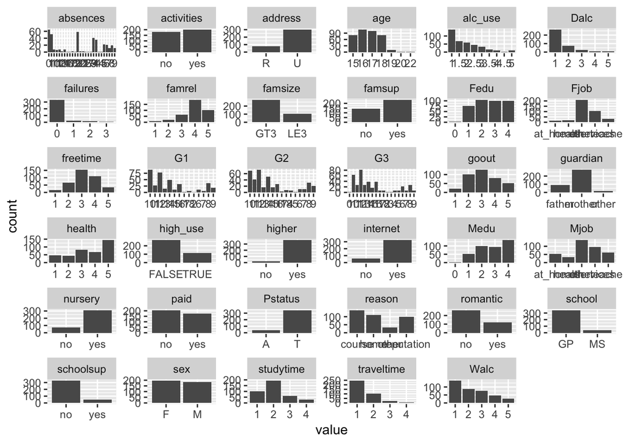

```r
gather(analysis.data) %>% ggplot(aes(value)) + facet_wrap("key", scales = "free") + geom_bar()
```

## Variables chosen for analysis

### age - Children’s age has been shown to be important for their alcohol consumption. (Reference for this -https://www.sciencedirect.com/science/article/pii/S2171206915000022)

### sex - Alcohol consumption could be gender linked as has been shown through previous research. Reference for this - https://www.ncbi.nlm.nih.gov/pmc/articles/PMC2844334/

### Pstatus - parent’s cohabitation status could be an important determinant in alcohol consumption. Parental divorce/separation is among the most commonly endorsed adverse childhood events and has been shown to increase subsequent risk of alcohol dependence and problems across adolescence and early adulthood. (Reference for this - https://www.ncbi.nlm.nih.gov/pmc/articles/PMC4916852/)

### famrel - This indicates the quality of family relationships and form a part of social variable for any child. Previous research (https://www.sciencedirect.com/science/article/pii/S2171206915000022) has shown to be such a case.

## Explore distributions of chosen variables and their relationships with alcohol consumption

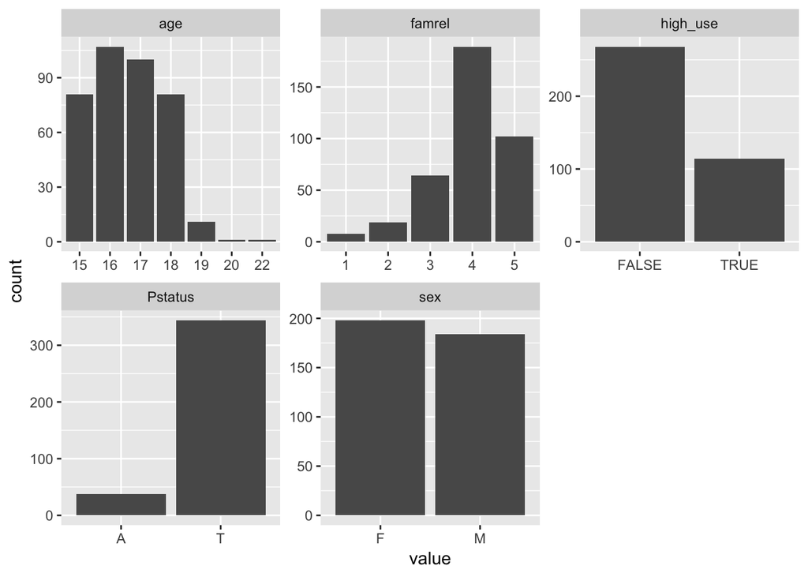

```r
library("dplyr")
chosen.data <- analysis.data[, c("age", "sex", "Pstatus", "famrel", "high_use")]

# Draw a bar plot of chosen variables
gather(chosen.data) %>% ggplot(aes(value)) + facet_wrap("key", scales = "free") + geom_bar()
```

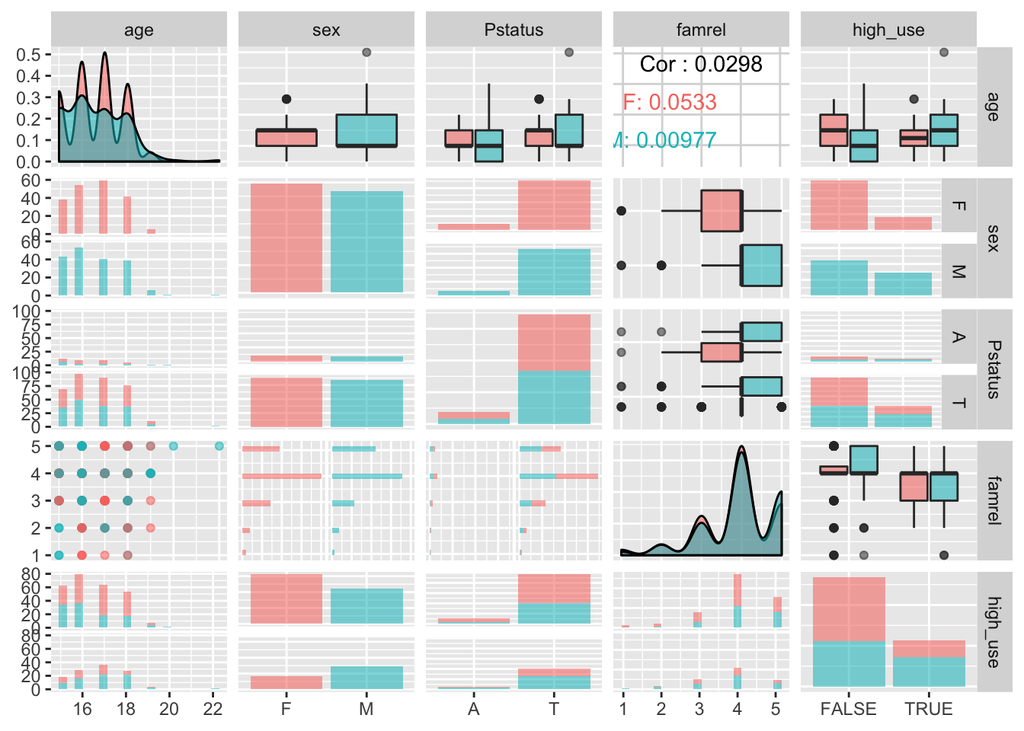

```r
# Draw a correlation plot of chosen variables
ggpairs(chosen.data, mapping = aes( col = sex, alpha = 0.2 ), lower = list(combo = wrap("facethist", bins = 20)))
```

```r
# Get cross tabulation tables for variables
library(gmodels)
CrossTable(chosen.data$sex, chosen.data$high_use)
```

```
##
##
##    Cell Contents
## |-------------------------|
## |                       N |
## | Chi-square contribution |
## |           N / Row Total |
## |           N / Col Total |
## |         N / Table Total |
## |-------------------------|
##
##
## Total Observations in Table:  382
##
##
##                 | chosen.data$high_use
## chosen.data$sex |     FALSE |      TRUE | Row Total |
## ----------------|-----------|-----------|-----------|
##               F |       156 |        42 |       198 |
##                 |     2.102 |     4.942 |           |
##                 |     0.788 |     0.212 |     0.518 |
##                 |     0.582 |     0.368 |           |
##                 |     0.408 |     0.110 |           |
## ----------------|-----------|-----------|-----------|
##               M |       112 |        72 |       184 |
##                 |     2.262 |     5.318 |           |
##                 |     0.609 |     0.391 |     0.482 |
##                 |     0.418 |     0.632 |           |
##                 |     0.293 |     0.188 |           |
## ----------------|-----------|-----------|-----------|
##    Column Total |       268 |       114 |       382 |
##                 |     0.702 |     0.298 |           |
## ----------------|-----------|-----------|-----------|
##
##
```

```r
CrossTable(chosen.data$age, chosen.data$high_use)
```

```
##
##
##    Cell Contents
## |-------------------------|
## |                       N |
## | Chi-square contribution |
## |           N / Row Total |
## |           N / Col Total |
## |         N / Table Total |
## |-------------------------|
##
##
## Total Observations in Table:  382
##
##
##                 | chosen.data$high_use
## chosen.data$age |     FALSE |      TRUE | Row Total |
## ----------------|-----------|-----------|-----------|
##              15 |        63 |        18 |        81 |
##                 |     0.671 |     1.576 |           |
##                 |     0.778 |     0.222 |     0.212 |
##                 |     0.235 |     0.158 |           |
##                 |     0.165 |     0.047 |           |
## ----------------|-----------|-----------|-----------|
##              16 |        79 |        28 |       107 |
##                 |     0.206 |     0.484 |           |
##                 |     0.738 |     0.262 |     0.280 |
##                 |     0.295 |     0.246 |           |
##                 |     0.207 |     0.073 |           |
## ----------------|-----------|-----------|-----------|
##              17 |        64 |        36 |       100 |
##                 |     0.540 |     1.270 |           |
##                 |     0.640 |     0.360 |     0.262 |
##                 |     0.239 |     0.316 |           |
##                 |     0.168 |     0.094 |           |
## ----------------|-----------|-----------|-----------|
##              18 |        54 |        27 |        81 |
##                 |     0.141 |     0.331 |           |
##                 |     0.667 |     0.333 |     0.212 |
##                 |     0.201 |     0.237 |           |
```

[output cut: 10 more lines]

```
##                 |     1.000 |     0.000 |     0.003 |
##                 |     0.004 |     0.000 |           |
##                 |     0.003 |     0.000 |           |
## ----------------|-----------|-----------|-----------|
##              22 |         0 |         1 |         1 |
##                 |     0.702 |     1.649 |           |
##                 |     0.000 |     1.000 |     0.003 |
##                 |     0.000 |     0.009 |           |
##                 |     0.000 |     0.003 |           |
## ----------------|-----------|-----------|-----------|
##    Column Total |       268 |       114 |       382 |
##                 |     0.702 |     0.298 |           |
## ----------------|-----------|-----------|-----------|
##
##
```

```r
CrossTable(chosen.data$Pstatus, chosen.data$high_use)
```

```
##
##
##    Cell Contents
## |-------------------------|
## |                       N |
## | Chi-square contribution |
## |           N / Row Total |
## |           N / Col Total |
## |         N / Table Total |
## |-------------------------|
##
##
## Total Observations in Table:  382
##
##
##                     | chosen.data$high_use
## chosen.data$Pstatus |     FALSE |      TRUE | Row Total |
## --------------------|-----------|-----------|-----------|
##                   A |        26 |        12 |        38 |
##                     |     0.016 |     0.038 |           |
##                     |     0.684 |     0.316 |     0.099 |
##                     |     0.097 |     0.105 |           |
##                     |     0.068 |     0.031 |           |
## --------------------|-----------|-----------|-----------|
##                   T |       242 |       102 |       344 |
##                     |     0.002 |     0.004 |           |
##                     |     0.703 |     0.297 |     0.901 |
##                     |     0.903 |     0.895 |           |
##                     |     0.634 |     0.267 |           |
## --------------------|-----------|-----------|-----------|
##        Column Total |       268 |       114 |       382 |
##                     |     0.702 |     0.298 |           |
## --------------------|-----------|-----------|-----------|
##
##
```

```r
CrossTable(chosen.data$famrel, chosen.data$high_use)
```

```
##
##
##    Cell Contents
## |-------------------------|
## |                       N |
## | Chi-square contribution |
## |           N / Row Total |
## |           N / Col Total |
## |         N / Table Total |
## |-------------------------|
##
##
## Total Observations in Table:  382
##
##
##                    | chosen.data$high_use
## chosen.data$famrel |     FALSE |      TRUE | Row Total |
## -------------------|-----------|-----------|-----------|
##                  1 |         6 |         2 |         8 |
##                    |     0.027 |     0.063 |           |
##                    |     0.750 |     0.250 |     0.021 |
##                    |     0.022 |     0.018 |           |
##                    |     0.016 |     0.005 |           |
## -------------------|-----------|-----------|-----------|
##                  2 |        10 |         9 |        19 |
##                    |     0.832 |     1.955 |           |
##                    |     0.526 |     0.474 |     0.050 |
##                    |     0.037 |     0.079 |           |
##                    |     0.026 |     0.024 |           |
## -------------------|-----------|-----------|-----------|
##                  3 |        39 |        25 |        64 |
##                    |     0.775 |     1.823 |           |
##                    |     0.609 |     0.391 |     0.168 |
##                    |     0.146 |     0.219 |           |
##                    |     0.102 |     0.065 |           |
## -------------------|-----------|-----------|-----------|
##                  4 |       135 |        54 |       189 |
##                    |     0.044 |     0.102 |           |
##                    |     0.714 |     0.286 |     0.495 |
##                    |     0.504 |     0.474 |           |
##                    |     0.353 |     0.141 |           |
## -------------------|-----------|-----------|-----------|
##                  5 |        78 |        24 |       102 |
##                    |     0.580 |     1.362 |           |
##                    |     0.765 |     0.235 |     0.267 |
##                    |     0.291 |     0.211 |           |
##                    |     0.204 |     0.063 |           |
## -------------------|-----------|-----------|-----------|
##       Column Total |       268 |       114 |       382 |
##                    |     0.702 |     0.298 |           |
## -------------------|-----------|-----------|-----------|
##
##
```

## Logistic regression to statistically explore the relationship further

```r
# Model with glm()
chosen.mod <- glm(high_use ~ Pstatus + age + sex + famrel, data = chosen.data, family = "binomial")
summary(chosen.mod)
```

```
##
## Call:
## glm(formula = high_use ~ Pstatus + age + sex + famrel, family = "binomial",
##     data = chosen.data)
##
## Deviance Residuals:
##     Min       1Q   Median       3Q      Max
## -1.5439  -0.8479  -0.6640   1.2254   2.0504
##
## Coefficients:
##             Estimate Std. Error z value Pr(>|z|)
## (Intercept) -3.88778    1.71500  -2.267   0.0234 *
## PstatusT    -0.13249    0.38409  -0.345   0.7301
## age          0.23479    0.09865   2.380   0.0173 *
## sexM         0.94515    0.23601   4.005 6.21e-05 ***
## famrel      -0.32119    0.12560  -2.557   0.0106 *
## ---
## Signif. codes:  0 '***' 0.001 '**' 0.01 '*' 0.05 '.' 0.1 ' ' 1
##
## (Dispersion parameter for binomial family taken to be 1)
##
##     Null deviance: 465.68  on 381  degrees of freedom
## Residual deviance: 438.92  on 377  degrees of freedom
## AIC: 448.92
##
## Number of Fisher Scoring iterations: 4
```

```r
# Compute odds ratios (OR)
chosen.mod.OR <- coef(chosen.mod) %>% exp

# Compute confidence intervals (CI)
confint(chosen.mod)
```

```
##                   2.5 %      97.5 %
## (Intercept) -7.29460682 -0.54975516
## PstatusT    -0.86780384  0.64983706
## age          0.04291218  0.43089580
## sexM         0.48770904  1.41454481
## famrel      -0.56968043 -0.07549712
```

```r
chosen.mod.CI <- confint(chosen.mod) %>% exp
# print out the odds ratios with their confidence intervals
cbind(chosen.mod.OR, chosen.mod.CI)
```

```
##             chosen.mod.OR        2.5 %    97.5 %
## (Intercept)    0.02049085 0.0006791919 0.5770911
## PstatusT       0.87590845 0.4198726450 1.9152287
## age            1.26464541 1.0438462211 1.5386352
## sexM           2.57320663 1.6285809238 4.1146131
## famrel         0.72528788 0.5657061903 0.9272824
```

### We see from above that alcohol use is significantly associated with gender (sex) and as seen from the summary of the model above that usage is highly more lnked with males than females (P-value = 6.21e-05). From the table detailing odds ratios & corresponding CI, we see that male students are 2.5 times more likely than female students.

### However, as suspected from the correlation plots/data distribution parental cohabitation status (Pstatus). And the OR for it is 0.8759084 less than 1. An OR of 1 indicates that odds for both living together(T) or apart(A) are equal and what we have here is that the odds for both parental statuses, are not associated with alcohol usage.

### Also, we see that family relationship (famrel) and student’s age (age) are weakly associated with alcohol usage and not so strongly as gender before, with p-values of 0.0106 and 0.0173 respectively.

## Predictive power of the model

```r
# predict() the probability of high_use
probabilities <- predict(chosen.mod, type = "response")

# add the predicted probabilities to 'alc'
chosen.data <- mutate(chosen.data, probability = probabilities)

# use the probabilities to make a prediction of high_use
chosen.data <- mutate(chosen.data, prediction = probabilities > 0.5)

# tabulate the target variable versus the predictions
table(high_use = chosen.data$high_use, prediction = chosen.data$prediction)
```

```
##         prediction
## high_use FALSE TRUE
##    FALSE   259    9
##    TRUE     98   16
```

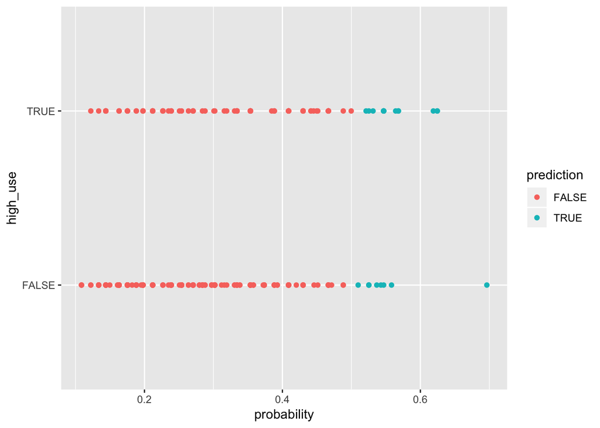

```r
# initialize a plot of 'high_use' versus 'probability' in 'alc'
g <- ggplot(chosen.data, aes(x = probability, y = high_use, col = prediction))

# define the geom as points and draw the plot
g + geom_point()
```

```r
# tabulate the target variable versus the predictions
table(high_use = chosen.data$high_use, prediction = chosen.data$prediction)
```

```
##         prediction
## high_use FALSE TRUE
##    FALSE   259    9
##    TRUE     98   16
```

```r
# Adjust the code: Use %>% to apply the prop.table() function on the output of table()
table(high_use = chosen.data$high_use, prediction = chosen.data$prediction) %>% prop.table()
```

```
##         prediction
## high_use      FALSE       TRUE
##    FALSE 0.67801047 0.02356021
##    TRUE  0.25654450 0.04188482
```

```r
#Adjust the code: Use %>% to apply the addmargins() function on the output of prop.table()
table(high_use = chosen.data$high_use, prediction = chosen.data$prediction) %>% prop.table() %>% addmargins()
```

```
##         prediction
## high_use      FALSE       TRUE        Sum
##    FALSE 0.67801047 0.02356021 0.70157068
##    TRUE  0.25654450 0.04188482 0.29842932
##    Sum   0.93455497 0.06544503 1.00000000
```

```r
# define a loss function (mean prediction error)
loss_func <- function(class, prob) {
  n_wrong <- abs(class - prob) > 0.5
  mean(n_wrong)
}

# call loss_func to compute the average number of wrong predictions in the (training) data using the above function
loss_func(class = chosen.data$high_use, prob = chosen.data$probability)
```

```
## [1] 0.2801047
```

```r
# Calculate missclassification error using an R package to confirm the above results
library(InformationValue)
optCutOff <- optimalCutoff(chosen.data$high_use, chosen.data$prediction)[1]
misClassError(chosen.data$high_use, chosen.data$prediction, threshold = optCutOff)
```

```
## [1] 0.2801
```

```r
# Calculating concordance
Concordance(chosen.data$high_use, chosen.data$prediction)
```

```
## $Concordance
## [1] 0.1356376
##
## $Discordance
## [1] 0.8643624
##
## $Tied
## [1] -1.110223e-16
##
## $Pairs
## [1] 30552
```

```r
# Calculating sensitivity/specificty of our model
sensitivity(chosen.data$high_use, chosen.data$prediction, threshold = optCutOff)
```

```
## [1] 0.1403509
```

```r
specificity(chosen.data$high_use, chosen.data$prediction, threshold = optCutOff)
```

```
## [1] 0.9664179
```

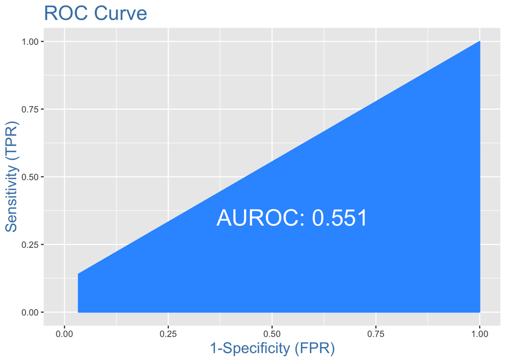

```r
# Construct an ROC curve
library(plotROC)
plotROC(chosen.data$high_use, chosen.data$prediction)
```

### One of the results gleaned from above is that the prediction errors calculated from using our-own defined function and teh R package, are lower than what was expected using the 4 set of predictors we have used here. The errors we have is 28% indicating that the above model has an accuracy of (1 - 0.28)% i.e., 72%.

### Sensitivity (or True Positive Rate) is the percentage of 1’s (actuals) correctly predicted by the model, while, specificity is the percentage of 0’s (actuals) correctly predicted. Specificity can also be calculated as 1-False Positive Rate. And we get a sensitivity of 14% which is quite low.

### Ideally, the model-calculated-probability-scores of all actual Positive’s, (aka Ones) should be greater than the model-calculated-probability-scores of ALL the Negatives (aka Zeroes). Such a model is said to be perfectly concordant and a highly reliable one. In simpler words, of all combinations of 1-0 pairs (actuals), Concordance is the percentage of pairs, whose scores of actual positive’s are greater than the scores of actual negative’s. For a perfect model, this will be 100%. So, the higher the concordance, the better is the quality of model. The above model with a concordance of 13.5% is quite a low quality model.

## Cross-validation

```r
## K-fold cross-validation
library(boot)

K <- nrow(chosen.data) #defines the leave-one-out method
cv_chosen <- cv.glm(data = chosen.data, cost = loss_func, glmfit = chosen.mod, K = 10)

## average number of wrong predictions in the cross validation
cv_chosen$delta[1]
```

```
## [1] 0.2827225
```

## Can we get a better model?

What we chose above is by intuition and secondary research, which is not always optimal as evidenced here by very poor predictive power, sensitivity and low concordance. One way to choose predictors which increase the prediction accuracy is by adding/dropping variables in successive models, such that all variable combinations are chosen and each model is compared with each other using a metric to find the model with highest prediction power. To do this, we use stepwise regression which would do this

```r
## Define big model to compare.
big.model <- glm(high_use ~ school + sex + age + address + famsize + Pstatus + G3 + failures + famrel +                famsup + freetime + goout + schoolsup + absences + health + Medu + Fedu +
                   activities + paid, data = analysis.data, family = binomial(link = "logit"))

## Define null model to compare.
null.model <- glm(high_use ~ 1, data = analysis.data, family = binomial(link = "logit"))

## Determining model with step procedure
step.model <- step(null.model, scope = list(upper = big.model), direction = "both",
             test = "Chisq", data = analysis.data)
```

```
## Start:  AIC=467.68
## high_use ~ 1
##
##              Df Deviance    AIC    LRT  Pr(>Chi)
## + goout       1   415.68 419.68 50.001 1.537e-12 ***
## + absences    1   447.45 451.45 18.233 1.955e-05 ***
## + sex         1   450.95 454.95 14.732 0.0001239 ***
## + freetime    1   456.84 460.84  8.840 0.0029469 **
## + failures    1   456.98 460.98  8.698 0.0031864 **
## + G3          1   459.43 463.43  6.252 0.0124059 *
## + age         1   460.83 464.83  4.851 0.0276320 *
## + famrel      1   460.92 464.92  4.756 0.0292035 *
## + address     1   462.30 466.30  3.375 0.0661994 .
## + famsize     1   463.48 467.48  2.200 0.1380308
## <none>            465.68 467.68
## + health      1   464.29 468.29  1.389 0.2385700
## + activities  1   464.43 468.43  1.245 0.2645257
## + schoolsup   1   464.51 468.51  1.165 0.2803902
## + paid        1   464.80 468.80  0.877 0.3491564
## + school      1   465.13 469.13  0.553 0.4572172
## + famsup      1   465.19 469.19  0.485 0.4860956
## + Fedu        1   465.46 469.46  0.215 0.6427752
## + Pstatus     1   465.62 469.62  0.060 0.8062405
## + Medu        1   465.63 469.63  0.046 0.8298479
## ---
## Signif. codes:  0 '***' 0.001 '**' 0.01 '*' 0.05 '.' 0.1 ' ' 1
##
## Step:  AIC=419.68
## high_use ~ goout
##
##              Df Deviance    AIC    LRT  Pr(>Chi)
## + absences    1   402.50 408.50 13.175 0.0002837 ***
## + sex         1   402.74 408.74 12.935 0.0003224 ***
## + famrel      1   408.12 414.12  7.562 0.0059609 **
## + address     1   409.72 415.72  5.960 0.0146306 *
## + failures    1   410.92 416.92  4.753 0.0292404 *
## + G3          1   413.39 419.39  2.293 0.1299925
## + health      1   413.42 419.42  2.263 0.1324990
## + famsize     1   413.51 419.51  2.166 0.1411078
## <none>            415.68 419.68
```

[output cut: 189 more lines]

```
## - activities  1   368.10 384.10  3.817 0.0507355 .
## + school      1   364.20 384.20  0.087 0.7678936
## + Medu        1   364.24 384.24  0.049 0.8248779
## + age         1   364.25 384.25  0.034 0.8532051
## + G3          1   364.27 384.27  0.020 0.8881974
## + schoolsup   1   364.28 384.28  0.005 0.9437839
## + Pstatus     1   364.29 384.29  0.000 0.9839522
## - paid        1   369.46 385.46  5.168 0.0230019 *
## - address     1   370.26 386.26  5.975 0.0145064 *
## - famrel      1   371.11 387.11  6.826 0.0089854 **
## - absences    1   378.63 394.63 14.345 0.0001522 ***
## - sex         1   382.40 398.40 18.113 2.081e-05 ***
## - goout       1   409.81 425.81 45.518 1.512e-11 ***
## ---
## Signif. codes:  0 '***' 0.001 '**' 0.01 '*' 0.05 '.' 0.1 ' ' 1
```

## Prediction of final model

```r
final.model.coeff <- as.data.frame(step.model$coefficients)
final.mod <- glm(high_use ~ sex + address + failures + famrel + goout + absences +
                   activities + paid, data = analysis.data, family = binomial(link = "logit"))
summary(final.mod)
```

```
##
## Call:
## glm(formula = high_use ~ sex + address + failures + famrel +
##     goout + absences + activities + paid, family = binomial(link = "logit"),
##     data = analysis.data)
##
## Deviance Residuals:
##     Min       1Q   Median       3Q      Max
## -1.8829  -0.7374  -0.4707   0.6885   2.8657
##
## Coefficients:
##               Estimate Std. Error z value Pr(>|z|)
## (Intercept)   -2.49941    0.73483  -3.401 0.000671 ***
## sexM           1.13462    0.27425   4.137 3.52e-05 ***
## addressU      -0.77509    0.31595  -2.453 0.014157 *
## failures       0.32272    0.21815   1.479 0.139051
## famrel        -0.37983    0.14566  -2.608 0.009119 **
## goout          0.80068    0.12880   6.217 5.08e-10 ***
## absences       0.08401    0.02218   3.788 0.000152 ***
## activitiesyes -0.51728    0.26676  -1.939 0.052487 .
## paidyes        0.61261    0.27244   2.249 0.024536 *
## ---
## Signif. codes:  0 '***' 0.001 '**' 0.01 '*' 0.05 '.' 0.1 ' ' 1
##
## (Dispersion parameter for binomial family taken to be 1)
##
##     Null deviance: 465.68  on 381  degrees of freedom
## Residual deviance: 364.29  on 373  degrees of freedom
## AIC: 382.29
##
## Number of Fisher Scoring iterations: 5
```

```r
# Get final model data
final.data <- analysis.data[, c("goout", "absences", "sex", "famrel", "address",
                                 "activities", "paid", "failures", "high_use")]

# predict() the probability of high_use
probabilities.final.mod <- predict(final.mod, type = "response")

# add the predicted probabilities to 'alc'
final.data <- mutate(final.data, probability = probabilities.final.mod)

# use the probabilities to make a prediction of high_use
final.data <- mutate(final.data, prediction = probabilities.final.mod > 0.5)

# tabulate the target variable versus the predictions
table(high_use = final.data$high_use, prediction = final.data$prediction)
```

```
##         prediction
## high_use FALSE TRUE
##    FALSE   252   16
##    TRUE     59   55
```

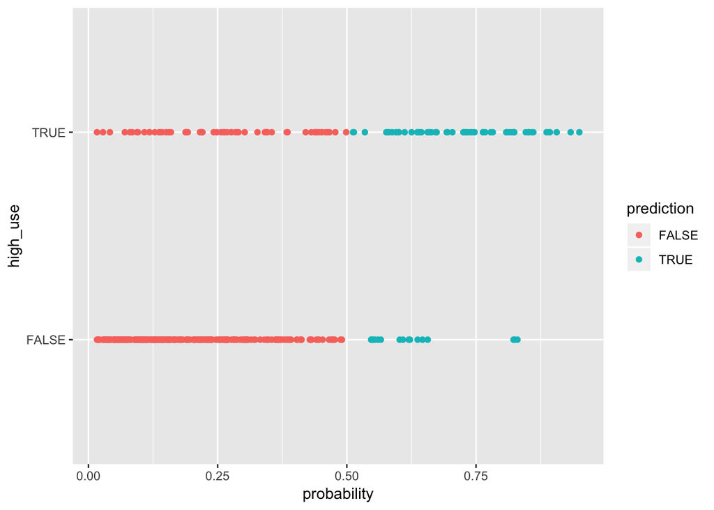

```r
# initialize a plot of 'high_use' versus 'probability' in 'alc'
g_final <- ggplot(final.data, aes(x = probability, y = high_use, col = prediction))

# define the geom as points and draw the plot
g_final + geom_point()
```

```r
# tabulate the target variable versus the predictions
table(high_use = final.data$high_use, prediction = final.data$prediction)
```

```
##         prediction
## high_use FALSE TRUE
##    FALSE   252   16
##    TRUE     59   55
```

```r
# Adjust the code: Use %>% to apply the prop.table() function on the output of table()
table(high_use = final.data$high_use, prediction = final.data$prediction) %>% prop.table()
```

```
##         prediction
## high_use      FALSE       TRUE
##    FALSE 0.65968586 0.04188482
##    TRUE  0.15445026 0.14397906
```

```r
#Adjust the code: Use %>% to apply the addmargins() function on the output of prop.table()
table(high_use = final.data$high_use, prediction = final.data$prediction) %>% prop.table() %>% addmargins()
```

```
##         prediction
## high_use      FALSE       TRUE        Sum
##    FALSE 0.65968586 0.04188482 0.70157068
##    TRUE  0.15445026 0.14397906 0.29842932
##    Sum   0.81413613 0.18586387 1.00000000
```

```r
# define a loss function (mean prediction error)
loss_func <- function(class, prob) {
  n_wrong <- abs(class - prob) > 0.5
  mean(n_wrong)
}

# call loss_func to compute the average number of wrong predictions in the (training) data using the above function
loss_func(class = final.data$high_use, prob = final.data$probability)
```

```
## [1] 0.1963351
```

```r
# Calculate missclassification error using an R package to confirm the above results
library(InformationValue)
optCutOff_final <- optimalCutoff(final.data$high_use, final.data$prediction)[1]
misClassError(final.data$high_use, final.data$prediction, threshold = optCutOff_final)
```

```
## [1] 0.1963
```

```r
# Calculating concordance
Concordance(final.data$high_use, final.data$prediction)
```

```
## $Concordance
## [1] 0.4536528
##
## $Discordance
## [1] 0.5463472
##
## $Tied
## [1] 0
##
## $Pairs
## [1] 30552
```

```r
# Calculating sensitivity/specificty of our model
sensitivity(final.data$high_use, final.data$prediction, threshold = optCutOff)
```

```
## [1] 0.4824561
```

```r
specificity(final.data$high_use, final.data$prediction, threshold = optCutOff)
```

```
## [1] 0.9402985
```

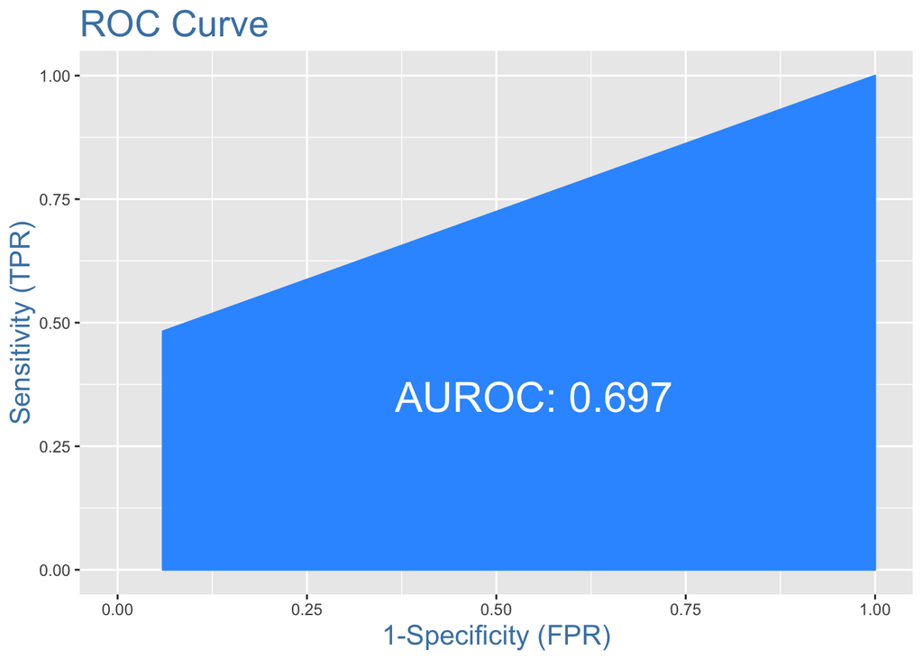

```r
# Construct an ROC curve
library(plotROC)

# ROC for Final chosen model
plotROC(final.data$high_use,  final.data$prediction)
```

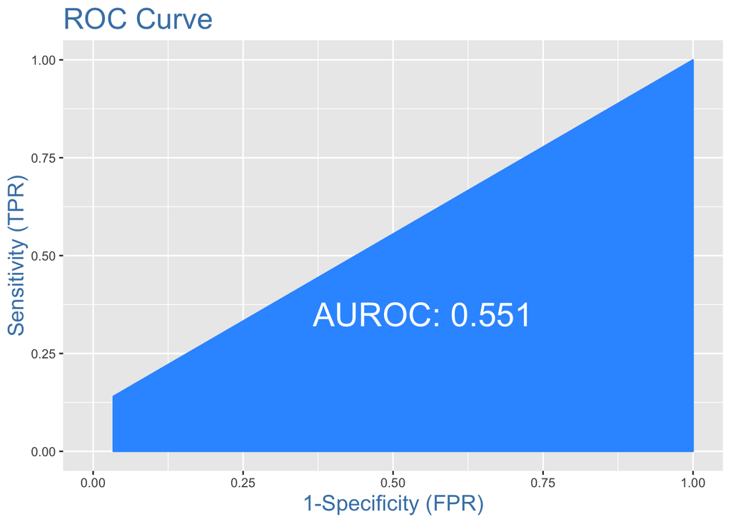

```r
# ROC for initially chosen model
plotROC(chosen.data$high_use, chosen.data$prediction)
```

```r
## K-fold cross-validation
library(boot)

K_final <- nrow(final.data) #defines the leave-one-out method
cv_final <- cv.glm(data = final.data, cost = loss_func, glmfit = final.mod, K = 10)

## average number of wrong predictions in the cross validation
cv_final$delta[1]
```

```
## [1] 0.2041885
```